# Looking Back at the Moneyball Era

###### March 4, 2024

**Note:** explanations for code will be in inline comments if not described in markdown.

## Key Question

We want to understand how efficient teams have been historically at spending money and getting wins in return. In the case of Moneyball, one would expect that:

1. Oakland was not much more efficient than other teams in their spending before 2000.
2. Oakland was much more efficient between 2000 and 2005 (they made a movie about it after all).

## Importing Dependencies

```python
# Remove the quiet flag to debug
!pip install numpy --quiet
!pip install pyarrow --quiet
!pip install pandas --quiet
!pip install html5lib --quiet
!pip install matplotlib --quiet
!pip install lxml --quiet
from datetime import datetime
import sqlite3
import numpy as np
import pandas as pd
import matplotlib.pyplot as plt
import re
```

## Setting Up Class Structure for SQL Interactions

```python
class DatabaseController():
    # Initialize sqlite connection
    def __init__(self):
        file = "lahman2014.sqlite"
        self.db = sqlite3.connect(file)

    # Return the result of a query as a pandas dataframe
    def get_query_as_df(self, query):
        return pd.read_sql(query, self.db)

    # Close the database connection
    def close(self):
        self.db.close()
```

## Part 1: Wrangling

### Problem 1

Compute a relation containing the total payroll and winning percentage (number of wins / number of games * 100) for each team.

**SQL Code:**

To create the relation between total payroll and win percentage, I used the following SQL query:

```
SELECT
            Teams.yearID,
            Teams.teamID,
            Teams.franchID,
            (Teams.W * 100.0 / Teams.G) AS win_percentage,
            Teams.W AS num_wins,
            Teams.G AS num_games,
            SUM(Salaries.salary) AS total_payroll
        FROM
            Teams
        LEFT JOIN
            Salaries ON Teams.yearID = Salaries.yearID AND Teams.teamID = Salaries.teamID
        WHERE
            Teams.yearID BETWEEN 1990 AND 2014
        GROUP BY
            Teams.yearID, Teams.teamID, Teams.franchID, Teams.W, Teams.G
        ORDER BY
            Teams.teamID;
```

**Code Explanation:**

1. Select relevant data from the Teams table (franchise, year, and team IDs).
2. Calculate win_percentage as a float by dividing team wins by total games played in a regular season.
3. Select the number of wins and games played.
4. Calculate total team payrolls by summing up player salary data from the Salaries table.
5. Use a left join to merge data from steps 1-4 with the Salaries table, where the team and year IDs are valid.
6. Use group by to summarize rows based on year, team, franchise, wins, and games played.
7. Sort the rows by team ID.

**Handling Missing Data:**

To ensure that the two tables were merged correctly, I used a left join to exclude any observations with NULL (aka missing) yearID or teamID data. There are 2 rows missing from the Teams table, so the result dataframe will have 728 rows instead of 730 (the number of rows in the payroll table). n.

```python
# Initialize database connection
db = DatabaseController()

# Create a query that gets the relation between payroll and win percentage
query = """
        SELECT
            Teams.yearID,
            Teams.teamID,
            Teams.franchID,
            (Teams.W * 100.0 / Teams.G) AS win_percentage,
            Teams.W AS num_wins,
            Teams.G AS num_games,
            SUM(Salaries.salary) AS total_payroll
        FROM
            Teams
        LEFT JOIN
            Salaries ON Teams.yearID = Salaries.yearID AND Teams.teamID = Salaries.teamID
        WHERE
            Teams.yearID BETWEEN 1990 AND 2014
        GROUP BY
            Teams.yearID, Teams.teamID, Teams.franchID, Teams.W, Teams.G
        ORDER BY
            Teams.teamID;"""

# Call query, and print result as pandas dataframe
p1_df = db.get_query_as_df(query)
p1_df
```

|  | yearID | teamID | franchID | win_percentage | num_wins | num_games | total_payroll |
| --- | --- | --- | --- | --- | --- | --- | --- |
| 0 | 1997 | ANA | ANA | 51.851852 | 84 | 162 | 31135472.0 |
| 1 | 1998 | ANA | ANA | 52.469136 | 85 | 162 | 41281000.0 |
| 2 | 1999 | ANA | ANA | 43.209877 | 70 | 162 | 55388166.0 |
| 3 | 2000 | ANA | ANA | 50.617284 | 82 | 162 | 51464167.0 |
| 4 | 2001 | ANA | ANA | 46.296296 | 75 | 162 | 47535167.0 |
| ... | ... | ... | ... | ... | ... | ... | ... |
| 723 | 2010 | WAS | WSN | 42.592593 | 69 | 162 | 61400000.0 |
| 724 | 2011 | WAS | WSN | 49.689441 | 80 | 161 | 63856928.0 |
| 725 | 2012 | WAS | WSN | 60.493827 | 98 | 162 | 80855143.0 |
| 726 | 2013 | WAS | WSN | 53.086420 | 86 | 162 | 113703270.0 |
| 727 | 2014 | WAS | WSN | 59.259259 | 96 | 162 | 131983680.0 |

728 rows × 7 columns

## Part 2: Exploratory Data Analysis

### Problem 2

Produce plots that illustrate the distribution of payrolls across teams conditioned on time (from 1990-2014).

#### Question 1

What statements can you make about the distribution of payrolls conditioned on time based on these plots?

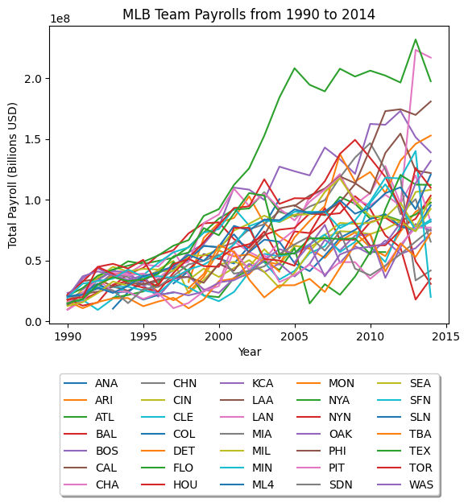

```python
plt.xlabel("Year")  # Add X-axis label
plt.ylabel("Total Payroll (Billions USD)")  # Add Y-axis label
plt.title("MLB Team Payrolls from 1990 to 2014")  # Add title

# Plot the payroll-over-time data for every team in MLB
for team in p1_df.teamID.unique():
    curr = p1_df[p1_df["teamID"] == team]
    plt.plot(curr[["yearID"]], curr[["total_payroll"]], label=f"{team}")

# Show a legend on the plot
plt.legend(loc='upper center', bbox_to_anchor=(0.5, -0.15),
          fancybox=True, shadow=True, ncol=5)

# Display the plot
plt.show()
```

### Problem 3

Produce plots that specifically show at least one of the statements made in Question 1.

1. Payrolls have increased overall. The median increases from < 0.5 billion in 1990 to almost 1.0 billion in 2014.
2. The payroll range has grown significantly. The whiskers spread further apart over the years.
3. Variation in payroll was lower before the Moneyball era. Interquartile ranges (which indicate spread/variability) grow quickly following the early 2000s.

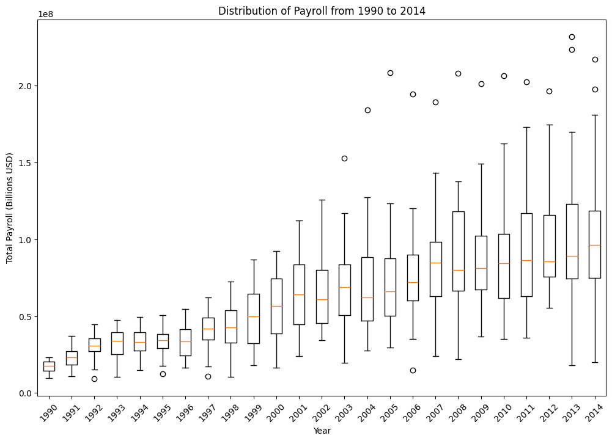

```python
plt.figure(figsize=(12, 8)) # Create a new figure
plt.xlabel("Year") # Add X-axis label
plt.ylabel("Total Payroll (Billions USD)") # Add Y-axis label
plt.title("Distribution of Payroll from 1990 to 2014") # Add title

# Create a box and whisker plot which shows the distribution of payrolls in MLB over time
plt.boxplot([p1_df[p1_df["yearID"] == year]["total_payroll"].dropna() for year in sorted(p1_df['yearID'].unique())])
plt.xticks(range(1, len(sorted(p1_df["yearID"].unique())) + 1), sorted(p1_df["yearID"].unique()), rotation=45)
plt.show()
```

### Problem 4

Make a scatterplot showing mean winning percentage (y-axis) vs. mean payroll (x-axis) for each of the five time periods.

#### Question 2

What can you say about team payrolls across these periods? Are there any teams that standout as being particularly good at paying for wins across these time periods? What can you say about the Oakland A's spending efficiency across these time periods?

**Key Takeaways:**

- Before the introduction of sabermetrics, the teams that won the most often spent the most (with few exceptions).
  - The New York Yankees (NYY), Atlanta Braves (ATL), and Toronto Blue Jays (TOR) dots are near the top in both mean payroll and win percentage.
  - The Washington Nationals/Montreal Expos (WSN) were exceptional from 1990-1994 considering their payroll, but other than that most of the teams that spent less won less than the Braves and Jays.
- After the Moneyball "experiment" from 2000-2004, the teams that spent less caught up to the teams that spent more in terms of win percentage.
  - The 1990-1994 and 2010-2014 time periods have similar linear regression lines, but their dot distributions differ greatly. In 1990-1994, more dots skew to the right side (higher payroll), but in 2010-2014 more dots skew to the left side (lower payroll). More low payroll teams (OAK, TBD for example) also fall above the regression line in 2010-2014. Thus, more teams chose to cut payroll and had the same/more success than the high payroll teams.
- Spending more isn't necessarily bad, but it is possible to get similar or even better results with less (aka increase efficiency).
  - Look at the Boston Red Sox (BOS) before and after adopting the Moneyball approach. In 1990-1994, they spent as much money as the Yankees, but won less than the Astros (HOU). From 2000-2004 (a time period in which they won a World Series), they were much more successful with less spending (they won well over 50% of games on average).
- The A's have gotten better/more efficient with their spending (less payroll, more wins).
  - From 1990-1994, they spent as much money as the Yankees and Jays, but fell below a mean win percentage of 50%. From 1995-1999 they won less, and also could not keep up with the Yankees spending power (look at the distances between their two points). From 2000 all the way to 2014, their payroll continued to stay small, but they won at least 50% of their games on average. From 2000-2004 in particular, they had a win percentage similar to the Yankees', but a payroll similar to the Tampa Bay Devil Rays (TBD).

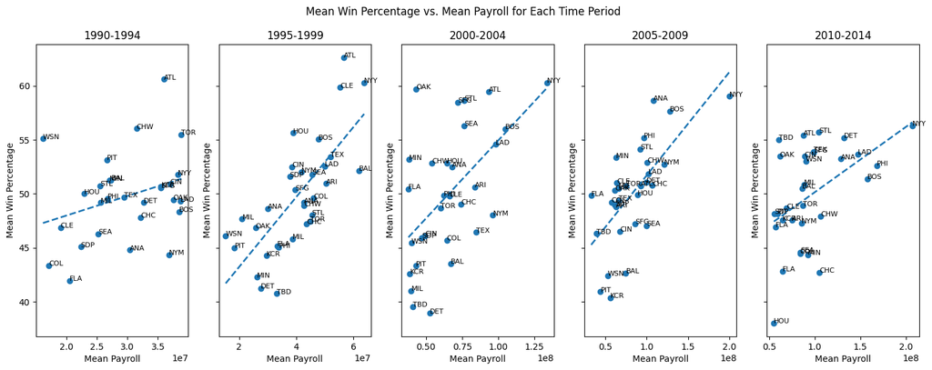

```python
# Discretize the dataframe into 5 time periods using the pandas cut function
p1_df["time_period"] = pd.cut(p1_df["yearID"], bins=[1990, 1994, 1999, 2004, 2009, 2014], labels=["1990-1994", "1995-1999", "2000-2004", "2005-2009", "2010-2014"])

# Make scatterplots showing mean winning percentage (y-axis) vs. mean payroll (x-axis) for each of the five time periods
fig, plots = plt.subplots(1, 5, figsize=(18, 6), sharey=True)

# Remove NaN from time periods first
periods = sorted(p1_df["time_period"].unique().dropna())

for i, time_period in enumerate(periods):
    df = p1_df[p1_df["time_period"] == time_period] # Get the rows for the current time period
    franchises = df.groupby("teamID")["franchID"].first()

    # Fit a linear regression with numpy
    x = df.groupby("teamID")["total_payroll"].mean() # Get the average payroll for each team during the time period
    y = df.groupby("teamID")["win_percentage"].mean() # Get the average win percentage for each team during the time period
    lin = np.polyfit(x, y, 1)
    poly = np.poly1d(lin)

    # Produce a scatter plot
    plots[i].scatter(x, y, label=time_period)
    plots[i].plot(np.unique(x), poly(np.unique(x)), linestyle="--", linewidth=2) # Plot the linear regression
    plots[i].set_title(f"{time_period}") # Add title
    plots[i].set_xlabel("Mean Payroll") # Add X-axis label
    plots[i].set_ylabel("Mean Win Percentage") # Add Y-axis label

    # Label each dot with the franchID
    for j, label in enumerate(franchises):
        plots[i].text(x.iloc[j], y.iloc[j], str(label), fontsize=8)


plt.suptitle("Mean Win Percentage vs. Mean Payroll for Each Time Period")
plt.show()
```

## Part 3: Data Transformations

### Problem 5

Create a new variable in your dataset that standardizes payroll conditioned on year.

```python
# Create a new variable that standardizes payroll conditioned on year, which is
# the payroll for each team/year subtracted by the average payroll in the year
# divided by the standard deviation of payroll in the year
p1_df["standardized_payroll"] = p1_df.groupby("yearID")["total_payroll"].transform(lambda x: (x - x.mean()) / x.std())

# Preview the new variable
p1_df[:10]
```

[output not shown]

### Problem 6

Repeat the same plots as Problem 4, but use this new standardized payroll variable.

#### Question 3

Discuss how the plots from Problem 4 and Problem 6 reflect the transformation you did on the payroll variable.

**Key Takeaways:**

- The plots from problem 6 and problem 4 show the same general trends (for example, wins increase as payroll increases from 1990-1994).
- The dot spread appears tighter in relation to the linear regressions in problem 6.
- The x-axis scales are different between problems 4 and 6. In problem 4, the scales shift from [0.5, 2.0] to [2, 6] which is fine if you only want to look at one graph, but not optimal for comparing time periods. In problem 6, the scales shift within [-2, 2], which is a lot more useful for comparing time periods. It is a lot easier to visually track how teams have reduced or increased payroll over the years (for example, OAK went from a mean standardized payroll of ~1 in 1990-1994 to -1 in 1995-1999).

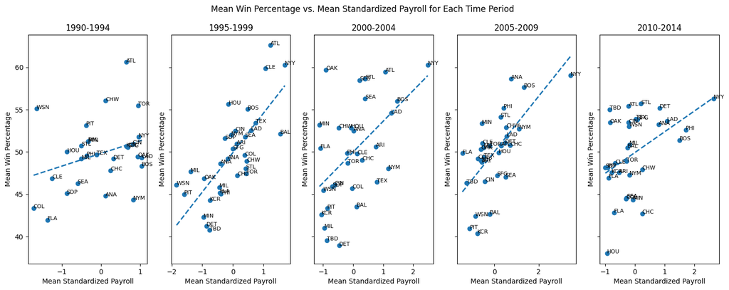

```python
# Replicate plots from problem 4, but use the standardized payroll variable instead

# Discretize the dataframe into 5 time periods using the pandas cut function
p1_df["time_period"] = pd.cut(p1_df["yearID"], bins=[1990, 1994, 1999, 2004, 2009, 2014], labels=["1990-1994", "1995-1999", "2000-2004", "2005-2009", "2010-2014"])

# Make scatterplots showing mean winning percentage (y-axis) vs. mean payroll (x-axis) for each of the five time periods
fig, plots = plt.subplots(1, 5, figsize=(18, 6), sharey=True)

# Remove NaN from time periods first
periods = sorted(p1_df["time_period"].unique().dropna())

for i, time_period in enumerate(periods):
    df = p1_df[p1_df["time_period"] == time_period] # Get the rows for the current time period
    franchises = df.groupby("teamID")["franchID"].first()

    # Fit a linear regression with numpy
    x = df.groupby("teamID")["standardized_payroll"].mean() # Get the average payroll for each team during the time period
    y = df.groupby("teamID")["win_percentage"].mean() # Get the average win percentage for each team during the time period
    lin = np.polyfit(x, y, 1)
    poly = np.poly1d(lin)

    # Produce a scatter plot
    plots[i].scatter(x, y, label=time_period)
    plots[i].plot(np.unique(x), poly(np.unique(x)), linestyle="--", linewidth=2) # Plot the linear regression
    plots[i].set_title(f"{time_period}") # Add title
    plots[i].set_xlabel("Mean Standardized Payroll") # Add X-axis label
    plots[i].set_ylabel("Mean Win Percentage") # Add Y-axis label

    # Label each dot with the franchID
    for j, label in enumerate(franchises):
        plots[i].text(x.iloc[j], y.iloc[j], str(label), fontsize=8)

# Name and show entire plot
plt.suptitle("Mean Win Percentage vs. Mean Standardized Payroll for Each Time Period")
plt.show()
```

### Problem 7

Make a single scatter plot of winning percentage (y-axis) vs. standardized payroll (x-axis). Add a regression line to highlight the relationship.

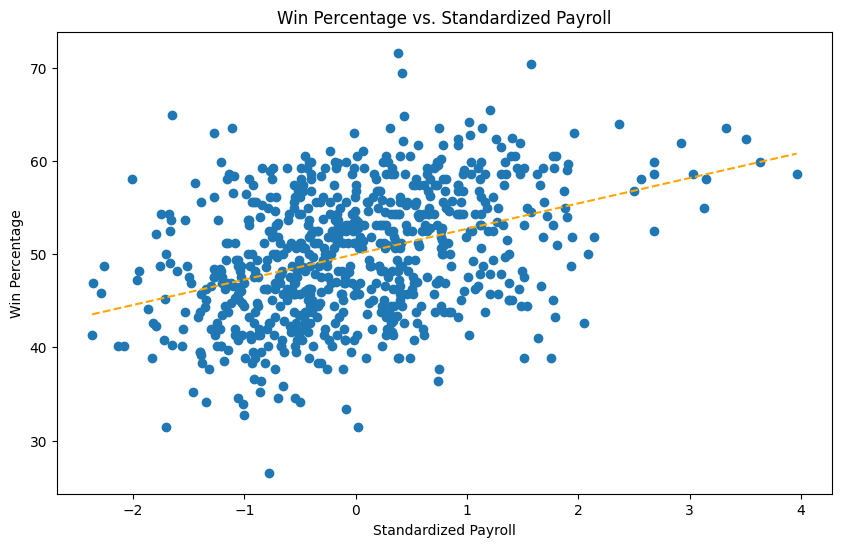

```python
plt.figure(figsize=(10, 6)) # Create new figure
plt.xlabel("Standardized Payroll") # Add X-axis label
plt.ylabel("Win Percentage") # Add Y-axis label
plt.title("Win Percentage vs. Standardized Payroll") # Add title

# Fit a linear regression line
lin = np.polyfit(p1_df["standardized_payroll"], p1_df["win_percentage"], 1)
poly = np.poly1d(lin)

# Produce a scatter plot
plt.scatter(p1_df["standardized_payroll"], p1_df["win_percentage"])
plt.plot(np.unique(p1_df["standardized_payroll"]), poly(np.unique(p1_df["standardized_payroll"])), linestyle="--", color="orange")

# Show plot
plt.show()
```

### Problem 8

Create a new field to compute each team's spending effiency, given by: $$efficiency_{ij} = win\_pct_{ij} - expected\_win\_pct_{ij}$$

#### Question 4

What can you learn from this plot compared to the set of plots you looked at in Question 2 and 3? How good was Oakland's efficiency during the Moneyball period?

The plots for questions 2 and 3 led us to believe that the Oakland A's were very efficient with their spending after implementing the Moneyball strategy. However, the spending efficiency plot suggests that the Oakland A's spending efficiency peaked during the Moneyball period (2000-2004), but was otherwise similar to many other teams. At their peak though, Oakland was as efficient as the late 1990s Yankees dynasty, but for a bit longer (the peak plateaus slightly). One thing to keep in mind is that the spending efficiency plot and question 2/3 plots are all imperfect, there are other factors that need to be taken into account (for example, postseason wins might impact spending efficiency more than regular season wins, especially if they lead to a championship title).

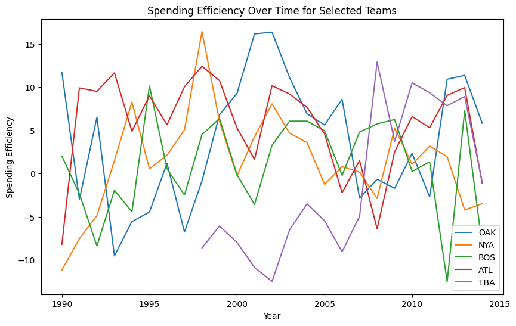

```python
# Create a new field for spending efficiency
p1_df["spending_efficiency"] = p1_df["win_percentage"] - (50 + (2.5 * p1_df["standardized_payroll"]))

# Select a few teams of interest (Oakland, New York Yankees, Boston, Atlanta, Tampa Bay)
selected_teams = ["OAK", "NYA", "BOS", "ATL", "TBA"]
selected_teams_df = p1_df[p1_df["teamID"].isin(selected_teams)]

# Create a line plot with year on the x-axis and efficiency on the y-axis
plt.figure(figsize=(10, 6))
plt.xlabel("Year") # Add X-axis label
plt.ylabel("Spending Efficiency") # Add Y-axis label
plt.title("Spending Efficiency Over Time for Selected Teams") # Add title

for team in selected_teams:
    team_data = selected_teams_df[selected_teams_df["teamID"] == team]
    plt.plot(team_data["yearID"], team_data["spending_efficiency"], label=f"{team}")

# Show legend
plt.legend()

# Show plot
plt.show()
```